# Data Mining on CHUSJ dataset

## Triangular version

*Including diagonal line*

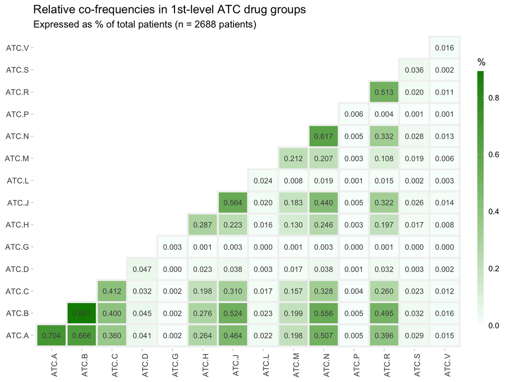

```r
# Reshape data to triangular heatmap
heatmap_triangularize <- function(ds) {
  # ds <- heatmap.data
  heatmap.data_aux <- reshape2::dcast(ds, x ~ y)
  n <- nrow(heatmap.data_aux)
  mat <- matrix(NA, n, n)
  mat[row(mat) + col(mat) > n] <- 1
  mat <- mat |> as.data.frame() |> rev()
  data_vector <- as.vector(as.matrix(mat)) * as.vector(as.matrix(heatmap.data_aux[, 2:(n+1)]))
  heatmap.data_triangular <- cbind(heatmap.data_aux$x, as.data.frame(matrix(data_vector, nrow = n)))
  names(heatmap.data_triangular) <- names(heatmap.data_aux)
  heatmap.data_triangular <- reshape2::melt(heatmap.data_triangular, value.name = "value", id.vars = "x")
  names(heatmap.data_triangular) <- c("x", "y", "value")
  heatmap.data_triangular <- heatmap.data_triangular[complete.cases(heatmap.data_triangular),]
  return(heatmap.data_triangular)
}



# Plot triangular heapmap v2
heatmap.data_triangular <- heatmap_triangularize(heatmap.data)
ggplot(heatmap.data_triangular, aes(x, y, fill = value)) +
  theme_light() +
  geom_tile(color = "grey95",
            lwd = 1,
            linetype = 1) +
  theme(axis.text.x = element_text(angle = 90),
        axis.title.x = element_blank(),
        axis.title.y = element_blank(),
        panel.border=element_blank(),
        panel.grid.major=element_line(color='white')) +
  ggtitle(label = "Relative co-frequencies in 1st-level ATC drug groups",
          subtitle = paste0("Expressed as % of total patients (n = ", nrow(ATC_lv1)," patients)")) +
  geom_text(aes(label = sprintf("%0.3f", value)), color = "gray30", size = 3) +
  # scale_fill_gradient(low = "lightsteelblue1", high = "darkolivegreen3") +
  scale_fill_gradient(low = "#F9FFFD", high = "#0C8A00") +
  guides(fill = guide_colourbar(barwidth = 0.5,
                                barheight = 20,
                                title = "%"))
```

# Fig.4 - ATC groups 2nd level

Heatmaps illustrating co-frequencies among 2nd level ATC drug groups for the most prevalent associations from the 1st level ATC drug group heatmap: (A) ATC A and B, (B) ATC A and N, (C) ATC B and N, and (D) ATC B and J. Each cell represents the relative co-frequency of patients using two drug groups concurrently. For instance, in the heatmap (A), the cell “ATC.B01 x ATC.A02” with a value of 0.333 indicates that 33.3% of the total patients (n=2688) are concurrently prescribed drugs from 2nd level ATC groups B01 and A02.

```r
heatmap_2groups <- function(index1 = NA,
                            index2 = NA,
                            verbose = TRUE) {

  #' This function plots a heatmap of 2 ATC groups at 2nd level
  #' inputs: the indexes on the 2nd levels codes for each group
  #'   ATC.A: 362:377 (16 codes)
  #'   ATC.B: 391:395 (5 codes)
  #'   ATC.J: 425:430 (6 codes)
  #'   ATC.N: 441:447 (7 codes)

  ATC_group1 <- BD_chusj[, index1]
  ATC_group2 <- BD_chusj[, index2]

  # Create an empty dataset
  heatmap.matrix <- data.frame(matrix(NA,
                                      ncol = ncol(ATC_group1),
                                      nrow = ncol(ATC_group2)))
  colnames(heatmap.matrix) <- names(ATC_group1)
  rownames(heatmap.matrix) <- names(ATC_group2)

  ATC_groups12 <- cbind(ATC_group1, ATC_group2)
  for (g1 in seq_along(ATC_group1)) {
    for (g2 in seq_along(ATC_group2)) {
      heatmap.matrix[g2, g1] <-
        nrow(ATC_groups12[, c(g1, g2 +
                                ncol(ATC_group1))][ATC_groups12[,g1] == 1 &
                                                     ATC_groups12[,g2 + ncol(ATC_group1)] == 1,])
    }
  }

  heatmap.data <- reshape2::melt(as.matrix(heatmap.matrix))
  colnames(heatmap.data) <- c("x", "y", "value")

  # change values to percentage
  heatmap.data$value <- round(heatmap.data$value / nrow(BD_chusj), digits = 3)

  family.group1 <- substring(names(ATC_group1)[1], 5, 5)
  family.group2 <- substring(names(ATC_group2)[1], 5, 5)

  p <-
    ggplot(heatmap.data, aes(x, y, fill = value)) +
    geom_tile(color = "grey95",
              lwd = 1,
              linetype = 1) +
    theme(axis.text.x = element_text(angle = 0),
          axis.title.x = element_blank(),
          axis.title.y = element_blank()) +
    ggtitle(label = paste("Relative co-frequences in 2nd-level ATC drug groups",
                          family.group1, "and", family.group2),
            subtitle = "Expressed as % of total patients (n = 2688)") +
    geom_text(aes(label = sprintf("%0.3f", value)), color = "gray30", size = 3) +
    # scale_fill_gradient(low = "lightsteelblue1", high = "darkolivegreen3") +
    scale_fill_gradient(low = "#F9FFFD", high = "#0C8A00") +
    # coord_fixed() +
    guides(fill = guide_colourbar(barwidth = 0.5,
                                  barheight = 7,
                                  title = "%"))

  # Find most prevalent combinations
  if (verbose) {
    heatmap.data %>%
      arrange(desc(value)) %>%
      mutate(perc = round(value / nrow(BD_chusj), 3)) %>%
      relocate(y) %>%
      rename(!!family.group1 := y, !!family.group2 := x, freq = value) %>%
      head() %>% print()
  }

  return(p)
}
```

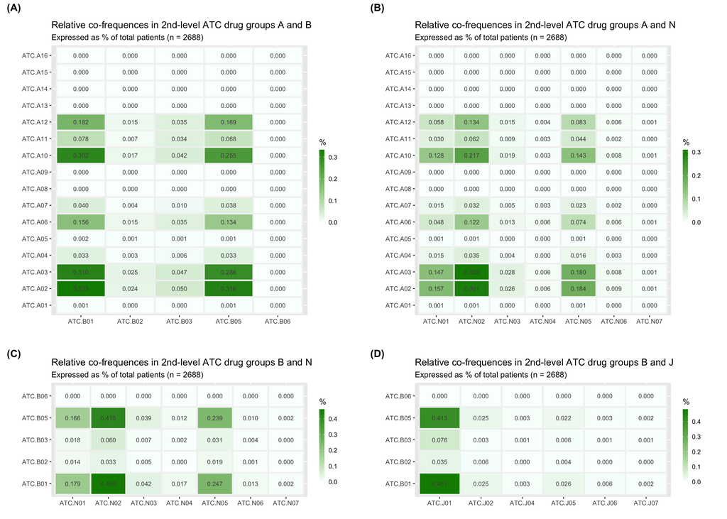

```r
# Plot all heatmaps together
p1 <- heatmap_2groups(index1 = 362:377, index2 = 391:395, verbose = F) # A.B
p2 <- heatmap_2groups(index1 = 391:395, index2 = 441:447, verbose = F) # B.N
p3 <- heatmap_2groups(index1 = 391:395, index2 = 425:430, verbose = F) # B.J
p4 <- heatmap_2groups(index1 = 362:377, index2 = 441:447, verbose = F) # A.N

cowplot::plot_grid(p1, p4, p2, p3,
                   ncol = 2,
                   nrow = 2,
                   rel_heights = c(2,1),
                   scale = 0.9,
                   labels = c("(A)", "(B)", "(C)", "(D)"),
                   label_size = 14
)
```